# Risk Factor Analysis

## Outcome Variable

**Outcome Variable:** y_rate_lencm

## Predictor Variables

**Intervention Variable:** hdlvry

**Adjustment Set:**

unadjusted

## Stratifying Variables

The analysis was stratified on these variable(s):

- diffcat
- studyid
- country

## Data Summary

| diffcat | studyid | country | hdlvry | n_cell | n |
| --- | --- | --- | --- | --- | --- |
| 0-3 months | ki1017093b-PROVIDE | BANGLADESH | 0 | 474 | 634 |
| 0-3 months | ki1017093b-PROVIDE | BANGLADESH | 1 | 160 | 634 |
| 3-6 months | ki1017093b-PROVIDE | BANGLADESH | 0 | 428 | 574 |
| 3-6 months | ki1017093b-PROVIDE | BANGLADESH | 1 | 146 | 574 |
| 6-12 months | ki1017093b-PROVIDE | BANGLADESH | 0 | 404 | 545 |
| 6-12 months | ki1017093b-PROVIDE | BANGLADESH | 1 | 141 | 545 |
| 12-24 months | ki1017093b-PROVIDE | BANGLADESH | 0 | 340 | 458 |
| 12-24 months | ki1017093b-PROVIDE | BANGLADESH | 1 | 118 | 458 |
| 0-3 months | ki1017093c-NIH-Crypto | BANGLADESH | 0 | 557 | 720 |
| 0-3 months | ki1017093c-NIH-Crypto | BANGLADESH | 1 | 163 | 720 |
| 3-6 months | ki1017093c-NIH-Crypto | BANGLADESH | 0 | 536 | 695 |
| 3-6 months | ki1017093c-NIH-Crypto | BANGLADESH | 1 | 159 | 695 |
| 6-12 months | ki1017093c-NIH-Crypto | BANGLADESH | 0 | 523 | 676 |
| 6-12 months | ki1017093c-NIH-Crypto | BANGLADESH | 1 | 153 | 676 |
| 12-24 months | ki1017093c-NIH-Crypto | BANGLADESH | 0 | 379 | 495 |
| 12-24 months | ki1017093c-NIH-Crypto | BANGLADESH | 1 | 116 | 495 |
| 0-3 months | kiGH5241-JiVitA-3 | BANGLADESH | 0 | 33 | 313 |
| 0-3 months | kiGH5241-JiVitA-3 | BANGLADESH | 1 | 280 | 313 |
| 3-6 months | kiGH5241-JiVitA-3 | BANGLADESH | 0 | 28 | 275 |
| 3-6 months | kiGH5241-JiVitA-3 | BANGLADESH | 1 | 247 | 275 |
| 6-12 months | kiGH5241-JiVitA-3 | BANGLADESH | 0 | 29 | 243 |
| 6-12 months | kiGH5241-JiVitA-3 | BANGLADESH | 1 | 214 | 243 |
| 12-24 months | kiGH5241-JiVitA-3 | BANGLADESH | 0 | 24 | 191 |
| 12-24 months | kiGH5241-JiVitA-3 | BANGLADESH | 1 | 167 | 191 |
| 0-3 months | kiGH5241-JiVitA-4 | BANGLADESH | 0 | 369 | 1796 |
| 0-3 months | kiGH5241-JiVitA-4 | BANGLADESH | 1 | 1427 | 1796 |
| 6-12 months | kiGH5241-JiVitA-4 | BANGLADESH | 0 | 750 | 2803 |
| 6-12 months | kiGH5241-JiVitA-4 | BANGLADESH | 1 | 2053 | 2803 |
| 12-24 months | kiGH5241-JiVitA-4 | BANGLADESH | 0 | 805 | 3107 |
| 12-24 months | kiGH5241-JiVitA-4 | BANGLADESH | 1 | 2302 | 3107 |

[output cut: 55 more lines]

The following strata were considered:

- diffcat: 0-3 months, studyid: ki1000108-CMC-V-BCS-2002, country: INDIA
- diffcat: 0-3 months, studyid: ki1000108-IRC, country: INDIA
- diffcat: 0-3 months, studyid: ki1000109-EE, country: PAKISTAN
- diffcat: 0-3 months, studyid: ki1000304b-SAS-CompFeed, country: INDIA
- diffcat: 0-3 months, studyid: ki1017093b-PROVIDE, country: BANGLADESH
- diffcat: 0-3 months, studyid: ki1017093c-NIH-Crypto, country: BANGLADESH
- diffcat: 0-3 months, studyid: ki1135781-COHORTS, country: INDIA
- diffcat: 0-3 months, studyid: kiGH5241-JiVitA-3, country: BANGLADESH
- diffcat: 0-3 months, studyid: kiGH5241-JiVitA-4, country: BANGLADESH
- diffcat: 12-24 months, studyid: ki1000108-CMC-V-BCS-2002, country: INDIA
- diffcat: 12-24 months, studyid: ki1000108-IRC, country: INDIA
- diffcat: 12-24 months, studyid: ki1000304-ZnMort, country: INDIA
- diffcat: 12-24 months, studyid: ki1017093b-PROVIDE, country: BANGLADESH
- diffcat: 12-24 months, studyid: ki1017093c-NIH-Crypto, country: BANGLADESH
- diffcat: 12-24 months, studyid: ki1066203-TanzaniaChild2, country: TANZANIA, UNITED REPUBLIC OF
- diffcat: 12-24 months, studyid: ki1113344-GMS-Nepal, country: NEPAL
- diffcat: 12-24 months, studyid: ki1135781-COHORTS, country: INDIA
- diffcat: 12-24 months, studyid: ki1148112-iLiNS-DYAD-M, country: MALAWI
- diffcat: 12-24 months, studyid: kiGH5241-JiVitA-3, country: BANGLADESH
- diffcat: 12-24 months, studyid: kiGH5241-JiVitA-4, country: BANGLADESH
- diffcat: 3-6 months, studyid: ki1000108-CMC-V-BCS-2002, country: INDIA
- diffcat: 3-6 months, studyid: ki1000108-IRC, country: INDIA
- diffcat: 3-6 months, studyid: ki1000109-EE, country: PAKISTAN
- diffcat: 3-6 months, studyid: ki1000304b-SAS-CompFeed, country: INDIA
- diffcat: 3-6 months, studyid: ki1017093b-PROVIDE, country: BANGLADESH
- diffcat: 3-6 months, studyid: ki1017093c-NIH-Crypto, country: BANGLADESH
- diffcat: 3-6 months, studyid: ki1066203-TanzaniaChild2, country: TANZANIA, UNITED REPUBLIC OF
- diffcat: 3-6 months, studyid: ki1113344-GMS-Nepal, country: NEPAL
- diffcat: 3-6 months, studyid: ki1135781-COHORTS, country: INDIA
- diffcat: 3-6 months, studyid: ki1148112-iLiNS-DYAD-M, country: MALAWI
- diffcat: 3-6 months, studyid: kiGH5241-JiVitA-3, country: BANGLADESH
- diffcat: 3-6 months, studyid: kiGH5241-JiVitA-4, country: BANGLADESH
- diffcat: 6-12 months, studyid: ki1000108-CMC-V-BCS-2002, country: INDIA
- diffcat: 6-12 months, studyid: ki1000108-IRC, country: INDIA
- diffcat: 6-12 months, studyid: ki1000109-EE, country: PAKISTAN
- diffcat: 6-12 months, studyid: ki1000304b-SAS-CompFeed, country: INDIA
- diffcat: 6-12 months, studyid: ki1000304b-SAS-FoodSuppl, country: INDIA
- diffcat: 6-12 months, studyid: ki1017093b-PROVIDE, country: BANGLADESH
- diffcat: 6-12 months, studyid: ki1017093c-NIH-Crypto, country: BANGLADESH
- diffcat: 6-12 months, studyid: ki1066203-TanzaniaChild2, country: TANZANIA, UNITED REPUBLIC OF
- diffcat: 6-12 months, studyid: ki1113344-GMS-Nepal, country: NEPAL
- diffcat: 6-12 months, studyid: ki1135781-COHORTS, country: INDIA
- diffcat: 6-12 months, studyid: ki1148112-iLiNS-DYAD-M, country: MALAWI
- diffcat: 6-12 months, studyid: kiGH5241-JiVitA-3, country: BANGLADESH
- diffcat: 6-12 months, studyid: kiGH5241-JiVitA-4, country: BANGLADESH

## Methods Detail

We’re interested in the causal parameters $E[Y_a]$ for all values of $a \in \mathcal{A}$. These parameters represent the mean outcome if, possibly contrary to fact, we intervened to set all units to have $A=a$. Under the randomization and positivity assumptions, these are identified by the statistical parameters $\psi_a=E_W[E_{Y|A,W}(Y|A=a,W)]$. In addition, we’re interested in the mean of $Y$, $E[Y]$ under no intervention (the observed mean). We will estimate these parameters by using SuperLearner to fit the relevant likelihood factors – $E_{Y|A,W}(Y|A=a,W)$ and $p(A=a|W)$, and then updating our likelihood fit using a joint TMLE.

For unadjusted analyses ($W=\{\}$), initial likelihoods were estimated using Lrnr_glm to estimate the simple $E(Y|A)$ and Lrnr_mean to estimate $p(A)$. For adjusted analyses, a small library containing Lrnr_glmnet, Lrnr_xgboost, and Lrnr_mean was used.

Having estimated these parameters, we will then use the delta method to estimate relative risks and attributable risks relative to a prespecified baseline level of $A$.

[output not shown]

[output cut: 25 more lines]

[output not shown]

# Results Detail

## Results Plots

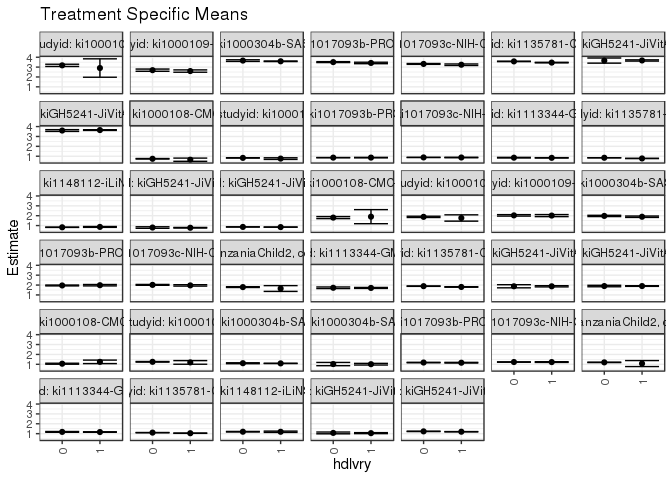

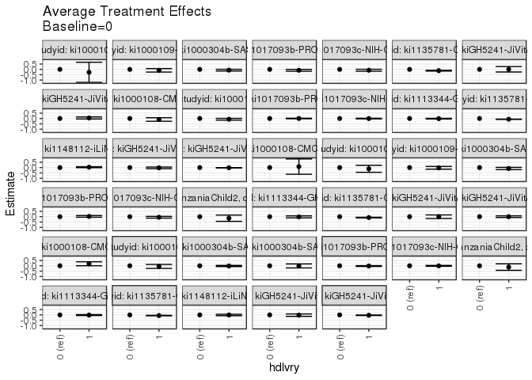

## Results Table

### Parameter: TSM

| diffcat | studyid | country | intervention_level | baseline_level | estimate | ci_lower | ci_upper |
| --- | --- | --- | --- | --- | --- | --- | --- |
| 0-3 months | ki1000108-IRC | INDIA | 0 | NA | 3.1779630 | 3.0653103 | 3.2906156 |
| 0-3 months | ki1000108-IRC | INDIA | 1 | NA | 2.9063845 | 1.9745063 | 3.8382627 |
| 0-3 months | ki1000109-EE | PAKISTAN | 0 | NA | 2.6897556 | 2.5777318 | 2.8017793 |
| 0-3 months | ki1000109-EE | PAKISTAN | 1 | NA | 2.5992810 | 2.4817614 | 2.7168006 |
| 0-3 months | ki1000304b-SAS-CompFeed | INDIA | 0 | NA | 3.6602019 | 3.5764455 | 3.7439583 |
| 0-3 months | ki1000304b-SAS-CompFeed | INDIA | 1 | NA | 3.5885262 | 3.5639330 | 3.6131193 |
| 0-3 months | ki1017093b-PROVIDE | BANGLADESH | 0 | NA | 3.5042441 | 3.4580294 | 3.5504587 |
| 0-3 months | ki1017093b-PROVIDE | BANGLADESH | 1 | NA | 3.4187592 | 3.3464343 | 3.4910840 |
| 0-3 months | ki1017093c-NIH-Crypto | BANGLADESH | 0 | NA | 3.3212440 | 3.2778157 | 3.3646723 |
| 0-3 months | ki1017093c-NIH-Crypto | BANGLADESH | 1 | NA | 3.2400635 | 3.1605667 | 3.3195602 |
| 0-3 months | ki1135781-COHORTS | INDIA | 0 | NA | 3.5768514 | 3.5553701 | 3.5983327 |
| 0-3 months | ki1135781-COHORTS | INDIA | 1 | NA | 3.4563394 | 3.4284649 | 3.4842139 |
| 0-3 months | kiGH5241-JiVitA-3 | BANGLADESH | 0 | NA | 3.6616561 | 3.4017001 | 3.9216121 |
| 0-3 months | kiGH5241-JiVitA-3 | BANGLADESH | 1 | NA | 3.6729713 | 3.6102406 | 3.7357020 |
| 0-3 months | kiGH5241-JiVitA-4 | BANGLADESH | 0 | NA | 3.5992715 | 3.5115552 | 3.6869879 |
| 0-3 months | kiGH5241-JiVitA-4 | BANGLADESH | 1 | NA | 3.6471459 | 3.6138939 | 3.6803979 |
| 3-6 months | ki1000108-CMC-V-BCS-2002 | INDIA | 0 | NA | 1.8068881 | 1.7046818 | 1.9090944 |
| 3-6 months | ki1000108-CMC-V-BCS-2002 | INDIA | 1 | NA | 1.9008428 | 1.1896067 | 2.6120788 |
| 3-6 months | ki1000108-IRC | INDIA | 0 | NA | 1.8829475 | 1.8181899 | 1.9477050 |
| 3-6 months | ki1000108-IRC | INDIA | 1 | NA | 1.7701196 | 1.4503290 | 2.0899102 |
| 3-6 months | ki1000109-EE | PAKISTAN | 0 | NA | 2.0321820 | 1.9571070 | 2.1072570 |
| 3-6 months | ki1000109-EE | PAKISTAN | 1 | NA | 2.0131852 | 1.9099108 | 2.1164596 |
| 3-6 months | ki1000304b-SAS-CompFeed | INDIA | 0 | NA | 1.9786777 | 1.9165197 | 2.0408357 |
| 3-6 months | ki1000304b-SAS-CompFeed | INDIA | 1 | NA | 1.8944205 | 1.8252930 | 1.9635480 |
| 3-6 months | ki1017093b-PROVIDE | BANGLADESH | 0 | NA | 1.9588685 | 1.9181104 | 1.9996267 |
| 3-6 months | ki1017093b-PROVIDE | BANGLADESH | 1 | NA | 1.9847256 | 1.9160509 | 2.0534003 |
| 3-6 months | ki1017093c-NIH-Crypto | BANGLADESH | 0 | NA | 2.0175559 | 1.9750729 | 2.0600390 |
| 3-6 months | ki1017093c-NIH-Crypto | BANGLADESH | 1 | NA | 1.9661580 | 1.8969975 | 2.0353184 |
| 3-6 months | ki1066203-TanzaniaChild2 | TANZANIA, UNITED REPUBLIC OF | 0 | NA | 1.7923965 | 1.7553491 | 1.8294440 |
| 3-6 months | ki1066203-TanzaniaChild2 | TANZANIA, UNITED REPUBLIC OF | 1 | NA | 1.6495462 | 1.3589956 | 1.9400968 |
| 3-6 months | ki1113344-GMS-Nepal | NEPAL | 0 | NA | 1.7252387 | 1.6431906 | 1.8072868 |
| 3-6 months | ki1113344-GMS-Nepal | NEPAL | 1 | NA | 1.7086066 | 1.6614112 | 1.7558019 |
| 3-6 months | ki1135781-COHORTS | INDIA | 0 | NA | 1.8886546 | 1.8701215 | 1.9071878 |
| 3-6 months | ki1135781-COHORTS | INDIA | 1 | NA | 1.8069033 | 1.7842125 | 1.8295941 |
| 3-6 months | kiGH5241-JiVitA-3 | BANGLADESH | 0 | NA | 1.8767695 | 1.7171555 | 2.0363836 |
| 3-6 months | kiGH5241-JiVitA-3 | BANGLADESH | 1 | NA | 1.8745764 | 1.8125792 | 1.9365736 |
| 3-6 months | kiGH5241-JiVitA-4 | BANGLADESH | 0 | NA | 1.8983509 | 1.8251495 | 1.9715523 |
| 3-6 months | kiGH5241-JiVitA-4 | BANGLADESH | 1 | NA | 1.8986227 | 1.8659633 | 1.9312821 |
| 6-12 months | ki1000108-CMC-V-BCS-2002 | INDIA | 0 | NA | 1.0590074 | 1.0102042 | 1.1078106 |
| 6-12 months | ki1000108-CMC-V-BCS-2002 | INDIA | 1 | NA | 1.2480272 | 1.0711403 | 1.4249140 |
| 6-12 months | ki1000108-IRC | INDIA | 0 | NA | 1.2497479 | 1.2201637 | 1.2793322 |
| 6-12 months | ki1000108-IRC | INDIA | 1 | NA | 1.1906904 | 1.0068629 | 1.3745179 |
| 6-12 months | ki1000304b-SAS-CompFeed | INDIA | 0 | NA | 1.1095804 | 1.0643572 | 1.1548037 |
| 6-12 months | ki1000304b-SAS-CompFeed | INDIA | 1 | NA | 1.0921072 | 1.0757977 | 1.1084167 |
| 6-12 months | ki1000304b-SAS-FoodSuppl | INDIA | 0 | NA | 1.0234658 | 0.8579254 | 1.1890061 |
| 6-12 months | ki1000304b-SAS-FoodSuppl | INDIA | 1 | NA | 1.0104865 | 0.9248825 | 1.0960906 |
| 6-12 months | ki1017093b-PROVIDE | BANGLADESH | 0 | NA | 1.1782443 | 1.1578954 | 1.1985931 |
| 6-12 months | ki1017093b-PROVIDE | BANGLADESH | 1 | NA | 1.1586550 | 1.1259601 | 1.1913499 |
| 6-12 months | ki1017093c-NIH-Crypto | BANGLADESH | 0 | NA | 1.2293315 | 1.2092216 | 1.2494414 |
| 6-12 months | ki1017093c-NIH-Crypto | BANGLADESH | 1 | NA | 1.2240285 | 1.1891596 | 1.2588974 |
| 6-12 months | ki1066203-TanzaniaChild2 | TANZANIA, UNITED REPUBLIC OF | 0 | NA | 1.1949316 | 1.1729305 | 1.2169328 |
| 6-12 months | ki1066203-TanzaniaChild2 | TANZANIA, UNITED REPUBLIC OF | 1 | NA | 1.0748591 | 0.7714657 | 1.3782524 |
| 6-12 months | ki1113344-GMS-Nepal | NEPAL | 0 | NA | 1.1788106 | 1.1410858 | 1.2165353 |
| 6-12 months | ki1113344-GMS-Nepal | NEPAL | 1 | NA | 1.1635569 | 1.1394960 | 1.1876177 |
| 6-12 months | ki1135781-COHORTS | INDIA | 0 | NA | 1.1066807 | 1.0942197 | 1.1191417 |
| 6-12 months | ki1135781-COHORTS | INDIA | 1 | NA | 1.0445726 | 1.0280547 | 1.0610905 |
| 6-12 months | ki1148112-iLiNS-DYAD-M | MALAWI | 0 | NA | 1.1964627 | 1.1708365 | 1.2220889 |
| 6-12 months | ki1148112-iLiNS-DYAD-M | MALAWI | 1 | NA | 1.1903726 | 1.1244903 | 1.2562549 |
| 6-12 months | kiGH5241-JiVitA-3 | BANGLADESH | 0 | NA | 1.0747746 | 0.9863249 | 1.1632242 |
| 6-12 months | kiGH5241-JiVitA-3 | BANGLADESH | 1 | NA | 1.0508257 | 1.0002118 | 1.1014396 |
| 6-12 months | kiGH5241-JiVitA-4 | BANGLADESH | 0 | NA | 1.2315511 | 1.2112941 | 1.2518081 |
| 6-12 months | kiGH5241-JiVitA-4 | BANGLADESH | 1 | NA | 1.1966400 | 1.1840693 | 1.2092108 |
| 12-24 months | ki1000108-CMC-V-BCS-2002 | INDIA | 0 | NA | 0.7400815 | 0.7133492 | 0.7668139 |
| 12-24 months | ki1000108-CMC-V-BCS-2002 | INDIA | 1 | NA | 0.6467578 | 0.4824516 | 0.8110641 |
| 12-24 months | ki1000108-IRC | INDIA | 0 | NA | 0.8309488 | 0.8111401 | 0.8507576 |
| 12-24 months | ki1000108-IRC | INDIA | 1 | NA | 0.7585329 | 0.6770278 | 0.8400381 |
| 12-24 months | ki1017093b-PROVIDE | BANGLADESH | 0 | NA | 0.8573361 | 0.8430517 | 0.8716205 |
| 12-24 months | ki1017093b-PROVIDE | BANGLADESH | 1 | NA | 0.8581737 | 0.8364276 | 0.8799198 |
| 12-24 months | ki1017093c-NIH-Crypto | BANGLADESH | 0 | NA | 0.8773553 | 0.8636526 | 0.8910581 |
| 12-24 months | ki1017093c-NIH-Crypto | BANGLADESH | 1 | NA | 0.8697494 | 0.8468582 | 0.8926406 |
| 12-24 months | ki1113344-GMS-Nepal | NEPAL | 0 | NA | 0.8512065 | 0.8231436 | 0.8792693 |
| 12-24 months | ki1113344-GMS-Nepal | NEPAL | 1 | NA | 0.8359606 | 0.8168517 | 0.8550695 |
| 12-24 months | ki1135781-COHORTS | INDIA | 0 | NA | 0.8430448 | 0.8356408 | 0.8504489 |
| 12-24 months | ki1135781-COHORTS | INDIA | 1 | NA | 0.7743190 | 0.7644029 | 0.7842352 |
| 12-24 months | ki1148112-iLiNS-DYAD-M | MALAWI | 0 | NA | 0.8270497 | 0.8107415 | 0.8433579 |
| 12-24 months | ki1148112-iLiNS-DYAD-M | MALAWI | 1 | NA | 0.8647312 | 0.8226579 | 0.9068044 |
| 12-24 months | kiGH5241-JiVitA-3 | BANGLADESH | 0 | NA | 0.8030273 | 0.7252140 | 0.8808405 |
| 12-24 months | kiGH5241-JiVitA-3 | BANGLADESH | 1 | NA | 0.7794865 | 0.7510652 | 0.8079077 |
| 12-24 months | kiGH5241-JiVitA-4 | BANGLADESH | 0 | NA | 0.8622563 | 0.8506503 | 0.8738622 |
| 12-24 months | kiGH5241-JiVitA-4 | BANGLADESH | 1 | NA | 0.8469622 | 0.8403229 | 0.8536016 |

### Parameter: E(Y)

| diffcat | studyid | country | intervention_level | baseline_level | estimate | ci_lower | ci_upper |
| --- | --- | --- | --- | --- | --- | --- | --- |
| 0-3 months | ki1000108-IRC | INDIA | NA | NA | 3.1729204 | 3.0609523 | 3.2848884 |
| 0-3 months | ki1000109-EE | PAKISTAN | NA | NA | 2.6584728 | 2.5745279 | 2.7424177 |
| 0-3 months | ki1000304b-SAS-CompFeed | INDIA | NA | NA | 3.5978528 | 3.5675578 | 3.6281478 |
| 0-3 months | ki1017093b-PROVIDE | BANGLADESH | NA | NA | 3.4826706 | 3.4434873 | 3.5218539 |
| 0-3 months | ki1017093c-NIH-Crypto | BANGLADESH | NA | NA | 3.3028656 | 3.2646714 | 3.3410598 |
| 0-3 months | ki1135781-COHORTS | INDIA | NA | NA | 3.5316726 | 3.5145737 | 3.5487714 |
| 0-3 months | kiGH5241-JiVitA-3 | BANGLADESH | NA | NA | 3.6717783 | 3.6046717 | 3.7388850 |
| 0-3 months | kiGH5241-JiVitA-4 | BANGLADESH | NA | NA | 3.6373098 | 3.6059106 | 3.6687089 |
| 3-6 months | ki1000108-CMC-V-BCS-2002 | INDIA | NA | NA | 1.8090444 | 1.7078462 | 1.9102427 |
| 3-6 months | ki1000108-IRC | INDIA | NA | NA | 1.8806738 | 1.8168757 | 1.9444719 |
| 3-6 months | ki1000109-EE | PAKISTAN | NA | NA | 2.0257728 | 1.9650303 | 2.0865152 |
| 3-6 months | ki1000304b-SAS-CompFeed | INDIA | NA | NA | 1.9057893 | 1.8442152 | 1.9673633 |
| 3-6 months | ki1017093b-PROVIDE | BANGLADESH | NA | NA | 1.9654454 | 1.9303798 | 2.0005110 |
| 3-6 months | ki1017093c-NIH-Crypto | BANGLADESH | NA | NA | 2.0057973 | 1.9693775 | 2.0422170 |
| 3-6 months | ki1066203-TanzaniaChild2 | TANZANIA, UNITED REPUBLIC OF | NA | NA | 1.7898602 | 1.7530949 | 1.8266255 |
| 3-6 months | ki1113344-GMS-Nepal | NEPAL | NA | NA | 1.7124798 | 1.6715373 | 1.7534223 |
| 3-6 months | ki1135781-COHORTS | INDIA | NA | NA | 1.8571473 | 1.8427398 | 1.8715548 |
| 3-6 months | kiGH5241-JiVitA-3 | BANGLADESH | NA | NA | 1.8747997 | 1.8153916 | 1.9342078 |
| 3-6 months | kiGH5241-JiVitA-4 | BANGLADESH | NA | NA | 1.8985588 | 1.8677350 | 1.9293826 |
| 6-12 months | ki1000108-CMC-V-BCS-2002 | INDIA | NA | NA | 1.0631293 | 1.0151394 | 1.1111193 |
| 6-12 months | ki1000108-IRC | INDIA | NA | NA | 1.2485668 | 1.2193308 | 1.2778028 |
| 6-12 months | ki1000304b-SAS-CompFeed | INDIA | NA | NA | 1.0945527 | 1.0814129 | 1.1076925 |
| 6-12 months | ki1000304b-SAS-FoodSuppl | INDIA | NA | NA | 1.0131058 | 0.9370457 | 1.0891660 |
| 6-12 months | ki1017093b-PROVIDE | BANGLADESH | NA | NA | 1.1731762 | 1.1558671 | 1.1904853 |
| 6-12 months | ki1017093c-NIH-Crypto | BANGLADESH | NA | NA | 1.2281313 | 1.2106849 | 1.2455776 |
| 6-12 months | ki1066203-TanzaniaChild2 | TANZANIA, UNITED REPUBLIC OF | NA | NA | 1.1937602 | 1.1717617 | 1.2157587 |
| 6-12 months | ki1113344-GMS-Nepal | NEPAL | NA | NA | 1.1671480 | 1.1467111 | 1.1875848 |
| 6-12 months | ki1135781-COHORTS | INDIA | NA | NA | 1.0832218 | 1.0732207 | 1.0932230 |
| 6-12 months | ki1148112-iLiNS-DYAD-M | MALAWI | NA | NA | 1.1958153 | 1.1718658 | 1.2197649 |
| 6-12 months | kiGH5241-JiVitA-3 | BANGLADESH | NA | NA | 1.0536838 | 1.0105552 | 1.0968123 |
| 6-12 months | kiGH5241-JiVitA-4 | BANGLADESH | NA | NA | 1.2059812 | 1.1951907 | 1.2167718 |
| 12-24 months | ki1000108-CMC-V-BCS-2002 | INDIA | NA | NA | 0.7380528 | 0.7116168 | 0.7644888 |
| 12-24 months | ki1000108-IRC | INDIA | NA | NA | 0.8294859 | 0.8099817 | 0.8489901 |
| 12-24 months | ki1017093b-PROVIDE | BANGLADESH | NA | NA | 0.8575519 | 0.8455586 | 0.8695452 |
| 12-24 months | ki1017093c-NIH-Crypto | BANGLADESH | NA | NA | 0.8755729 | 0.8637860 | 0.8873598 |
| 12-24 months | ki1113344-GMS-Nepal | NEPAL | NA | NA | 0.8398056 | 0.8238438 | 0.8557674 |
| 12-24 months | ki1135781-COHORTS | INDIA | NA | NA | 0.8173099 | 0.8112554 | 0.8233643 |
| 12-24 months | ki1148112-iLiNS-DYAD-M | MALAWI | NA | NA | 0.8314368 | 0.8161791 | 0.8466945 |
| 12-24 months | kiGH5241-JiVitA-3 | BANGLADESH | NA | NA | 0.7824445 | 0.7538031 | 0.8110859 |
| 12-24 months | kiGH5241-JiVitA-4 | BANGLADESH | NA | NA | 0.8509248 | 0.8449817 | 0.8568678 |

### Parameter: ATE

| diffcat | studyid | country | intervention_level | baseline_level | estimate | ci_lower | ci_upper |
| --- | --- | --- | --- | --- | --- | --- | --- |
| 0-3 months | ki1000108-IRC | INDIA | 0 | 0 | 0.0000000 | 0.0000000 | 0.0000000 |
| 0-3 months | ki1000108-IRC | INDIA | 1 | 0 | -0.2715785 | -1.2102411 | 0.6670842 |
| 0-3 months | ki1000109-EE | PAKISTAN | 0 | 0 | 0.0000000 | 0.0000000 | 0.0000000 |
| 0-3 months | ki1000109-EE | PAKISTAN | 1 | 0 | -0.0904745 | -0.2528327 | 0.0718836 |
| 0-3 months | ki1000304b-SAS-CompFeed | INDIA | 0 | 0 | 0.0000000 | 0.0000000 | 0.0000000 |
| 0-3 months | ki1000304b-SAS-CompFeed | INDIA | 1 | 0 | -0.0716758 | -0.1531391 | 0.0097876 |
| 0-3 months | ki1017093b-PROVIDE | BANGLADESH | 0 | 0 | 0.0000000 | 0.0000000 | 0.0000000 |
| 0-3 months | ki1017093b-PROVIDE | BANGLADESH | 1 | 0 | -0.0854849 | -0.1713142 | 0.0003445 |
| 0-3 months | ki1017093c-NIH-Crypto | BANGLADESH | 0 | 0 | 0.0000000 | 0.0000000 | 0.0000000 |
| 0-3 months | ki1017093c-NIH-Crypto | BANGLADESH | 1 | 0 | -0.0811805 | -0.1717661 | 0.0094051 |
| 0-3 months | ki1135781-COHORTS | INDIA | 0 | 0 | 0.0000000 | 0.0000000 | 0.0000000 |
| 0-3 months | ki1135781-COHORTS | INDIA | 1 | 0 | -0.1205120 | -0.1557034 | -0.0853206 |
| 0-3 months | kiGH5241-JiVitA-3 | BANGLADESH | 0 | 0 | 0.0000000 | 0.0000000 | 0.0000000 |
| 0-3 months | kiGH5241-JiVitA-3 | BANGLADESH | 1 | 0 | 0.0113152 | -0.2440318 | 0.2666621 |
| 0-3 months | kiGH5241-JiVitA-4 | BANGLADESH | 0 | 0 | 0.0000000 | 0.0000000 | 0.0000000 |
| 0-3 months | kiGH5241-JiVitA-4 | BANGLADESH | 1 | 0 | 0.0478743 | -0.0470926 | 0.1428413 |
| 3-6 months | ki1000108-CMC-V-BCS-2002 | INDIA | 0 | 0 | 0.0000000 | 0.0000000 | 0.0000000 |
| 3-6 months | ki1000108-CMC-V-BCS-2002 | INDIA | 1 | 0 | 0.0939547 | -0.6245875 | 0.8124969 |
| 3-6 months | ki1000108-IRC | INDIA | 0 | 0 | 0.0000000 | 0.0000000 | 0.0000000 |
| 3-6 months | ki1000108-IRC | INDIA | 1 | 0 | -0.1128279 | -0.4391093 | 0.2134535 |
| 3-6 months | ki1000109-EE | PAKISTAN | 0 | 0 | 0.0000000 | 0.0000000 | 0.0000000 |
| 3-6 months | ki1000109-EE | PAKISTAN | 1 | 0 | -0.0189968 | -0.1466755 | 0.1086819 |
| 3-6 months | ki1000304b-SAS-CompFeed | INDIA | 0 | 0 | 0.0000000 | 0.0000000 | 0.0000000 |
| 3-6 months | ki1000304b-SAS-CompFeed | INDIA | 1 | 0 | -0.0842572 | -0.1898260 | 0.0213116 |
| 3-6 months | ki1017093b-PROVIDE | BANGLADESH | 0 | 0 | 0.0000000 | 0.0000000 | 0.0000000 |
| 3-6 months | ki1017093b-PROVIDE | BANGLADESH | 1 | 0 | 0.0258570 | -0.0540019 | 0.1057159 |
| 3-6 months | ki1017093c-NIH-Crypto | BANGLADESH | 0 | 0 | 0.0000000 | 0.0000000 | 0.0000000 |
| 3-6 months | ki1017093c-NIH-Crypto | BANGLADESH | 1 | 0 | -0.0513980 | -0.1325643 | 0.0297684 |
| 3-6 months | ki1066203-TanzaniaChild2 | TANZANIA, UNITED REPUBLIC OF | 0 | 0 | 0.0000000 | 0.0000000 | 0.0000000 |
| 3-6 months | ki1066203-TanzaniaChild2 | TANZANIA, UNITED REPUBLIC OF | 1 | 0 | -0.1428503 | -0.4357533 | 0.1500526 |
| 3-6 months | ki1113344-GMS-Nepal | NEPAL | 0 | 0 | 0.0000000 | 0.0000000 | 0.0000000 |
| 3-6 months | ki1113344-GMS-Nepal | NEPAL | 1 | 0 | -0.0166321 | -0.1112856 | 0.0780214 |
| 3-6 months | ki1135781-COHORTS | INDIA | 0 | 0 | 0.0000000 | 0.0000000 | 0.0000000 |
| 3-6 months | ki1135781-COHORTS | INDIA | 1 | 0 | -0.0817513 | -0.1110490 | -0.0524537 |
| 3-6 months | kiGH5241-JiVitA-3 | BANGLADESH | 0 | 0 | 0.0000000 | 0.0000000 | 0.0000000 |
| 3-6 months | kiGH5241-JiVitA-3 | BANGLADESH | 1 | 0 | -0.0021931 | -0.1681489 | 0.1637626 |
| 3-6 months | kiGH5241-JiVitA-4 | BANGLADESH | 0 | 0 | 0.0000000 | 0.0000000 | 0.0000000 |
| 3-6 months | kiGH5241-JiVitA-4 | BANGLADESH | 1 | 0 | 0.0002718 | -0.0788431 | 0.0793868 |
| 6-12 months | ki1000108-CMC-V-BCS-2002 | INDIA | 0 | 0 | 0.0000000 | 0.0000000 | 0.0000000 |
| 6-12 months | ki1000108-CMC-V-BCS-2002 | INDIA | 1 | 0 | 0.1890198 | 0.0055240 | 0.3725156 |
| 6-12 months | ki1000108-IRC | INDIA | 0 | 0 | 0.0000000 | 0.0000000 | 0.0000000 |
| 6-12 months | ki1000108-IRC | INDIA | 1 | 0 | -0.0590575 | -0.2452504 | 0.1271353 |
| 6-12 months | ki1000304b-SAS-CompFeed | INDIA | 0 | 0 | 0.0000000 | 0.0000000 | 0.0000000 |
| 6-12 months | ki1000304b-SAS-CompFeed | INDIA | 1 | 0 | -0.0174732 | -0.0699940 | 0.0350475 |
| 6-12 months | ki1000304b-SAS-FoodSuppl | INDIA | 0 | 0 | 0.0000000 | 0.0000000 | 0.0000000 |
| 6-12 months | ki1000304b-SAS-FoodSuppl | INDIA | 1 | 0 | -0.0129792 | -0.1993436 | 0.1733851 |
| 6-12 months | ki1017093b-PROVIDE | BANGLADESH | 0 | 0 | 0.0000000 | 0.0000000 | 0.0000000 |
| 6-12 months | ki1017093b-PROVIDE | BANGLADESH | 1 | 0 | -0.0195893 | -0.0580995 | 0.0189209 |
| 6-12 months | ki1017093c-NIH-Crypto | BANGLADESH | 0 | 0 | 0.0000000 | 0.0000000 | 0.0000000 |
| 6-12 months | ki1017093c-NIH-Crypto | BANGLADESH | 1 | 0 | -0.0053030 | -0.0455553 | 0.0349494 |
| 6-12 months | ki1066203-TanzaniaChild2 | TANZANIA, UNITED REPUBLIC OF | 0 | 0 | 0.0000000 | 0.0000000 | 0.0000000 |
| 6-12 months | ki1066203-TanzaniaChild2 | TANZANIA, UNITED REPUBLIC OF | 1 | 0 | -0.1200726 | -0.4242626 | 0.1841175 |
| 6-12 months | ki1113344-GMS-Nepal | NEPAL | 0 | 0 | 0.0000000 | 0.0000000 | 0.0000000 |
| 6-12 months | ki1113344-GMS-Nepal | NEPAL | 1 | 0 | -0.0152537 | -0.0599983 | 0.0294909 |
| 6-12 months | ki1135781-COHORTS | INDIA | 0 | 0 | 0.0000000 | 0.0000000 | 0.0000000 |
| 6-12 months | ki1135781-COHORTS | INDIA | 1 | 0 | -0.0621081 | -0.0827991 | -0.0414171 |
| 6-12 months | ki1148112-iLiNS-DYAD-M | MALAWI | 0 | 0 | 0.0000000 | 0.0000000 | 0.0000000 |
| 6-12 months | ki1148112-iLiNS-DYAD-M | MALAWI | 1 | 0 | -0.0060900 | -0.0767808 | 0.0646007 |
| 6-12 months | kiGH5241-JiVitA-3 | BANGLADESH | 0 | 0 | 0.0000000 | 0.0000000 | 0.0000000 |
| 6-12 months | kiGH5241-JiVitA-3 | BANGLADESH | 1 | 0 | -0.0239489 | -0.1356547 | 0.0877570 |
| 6-12 months | kiGH5241-JiVitA-4 | BANGLADESH | 0 | 0 | 0.0000000 | 0.0000000 | 0.0000000 |
| 6-12 months | kiGH5241-JiVitA-4 | BANGLADESH | 1 | 0 | -0.0349111 | -0.0586363 | -0.0111859 |
| 12-24 months | ki1000108-CMC-V-BCS-2002 | INDIA | 0 | 0 | 0.0000000 | 0.0000000 | 0.0000000 |
| 12-24 months | ki1000108-CMC-V-BCS-2002 | INDIA | 1 | 0 | -0.0933237 | -0.2597904 | 0.0731430 |
| 12-24 months | ki1000108-IRC | INDIA | 0 | 0 | 0.0000000 | 0.0000000 | 0.0000000 |
| 12-24 months | ki1000108-IRC | INDIA | 1 | 0 | -0.0724159 | -0.1562936 | 0.0114618 |
| 12-24 months | ki1017093b-PROVIDE | BANGLADESH | 0 | 0 | 0.0000000 | 0.0000000 | 0.0000000 |
| 12-24 months | ki1017093b-PROVIDE | BANGLADESH | 1 | 0 | 0.0008376 | -0.0251804 | 0.0268556 |
| 12-24 months | ki1017093c-NIH-Crypto | BANGLADESH | 0 | 0 | 0.0000000 | 0.0000000 | 0.0000000 |
| 12-24 months | ki1017093c-NIH-Crypto | BANGLADESH | 1 | 0 | -0.0076059 | -0.0342850 | 0.0190732 |
| 12-24 months | ki1113344-GMS-Nepal | NEPAL | 0 | 0 | 0.0000000 | 0.0000000 | 0.0000000 |
| 12-24 months | ki1113344-GMS-Nepal | NEPAL | 1 | 0 | -0.0152458 | -0.0491969 | 0.0187052 |
| 12-24 months | ki1135781-COHORTS | INDIA | 0 | 0 | 0.0000000 | 0.0000000 | 0.0000000 |
| 12-24 months | ki1135781-COHORTS | INDIA | 1 | 0 | -0.0687258 | -0.0811012 | -0.0563504 |
| 12-24 months | ki1148112-iLiNS-DYAD-M | MALAWI | 0 | 0 | 0.0000000 | 0.0000000 | 0.0000000 |
| 12-24 months | ki1148112-iLiNS-DYAD-M | MALAWI | 1 | 0 | 0.0376814 | -0.0074419 | 0.0828047 |
| 12-24 months | kiGH5241-JiVitA-3 | BANGLADESH | 0 | 0 | 0.0000000 | 0.0000000 | 0.0000000 |
| 12-24 months | kiGH5241-JiVitA-3 | BANGLADESH | 1 | 0 | -0.0235408 | -0.1009144 | 0.0538328 |
| 12-24 months | kiGH5241-JiVitA-4 | BANGLADESH | 0 | 0 | 0.0000000 | 0.0000000 | 0.0000000 |
| 12-24 months | kiGH5241-JiVitA-4 | BANGLADESH | 1 | 0 | -0.0152940 | -0.0282267 | -0.0023614 |